# Peer-graded Assignment: Statistical Inference Course Project

Marco Pasin

19 aprile 2017

## Instructions

The project is part of the course “Statistical Inference” offered by Johns Hopkins University through Coursera. It consists of two parts:

- A simulation exercise.
- Some basic inferential data analysis.

# Part 1: Simulation Exercise

In this part we will investigate the exponential distribution in R and compare it with the Central Limit Theorem. The exponential distribution can be simulated in R with rexp(n, lambda) where lambda is the rate parameter. The mean of exponential distribution is 1/lambda and the standard deviation is also 1/lambda. Set lambda = 0.2 for all of the simulations. We will investigate the distribution of averages of 40 exponentials. Note that we will need to do a thousand simulations.

### Set parameters of theoretical distribution

```r
lambda<-0.2

#The theoretical mean is 1/lambda, which is 5
theory_mn<-1/lambda

#Standard deviation is also 1/lambda
sd<-1/lambda
```

Let’s build a theoretical distribution made of a large collection of random exponentials, e.g. 10000 exponentials and plot it with a histogram to see what the distribution looks like.

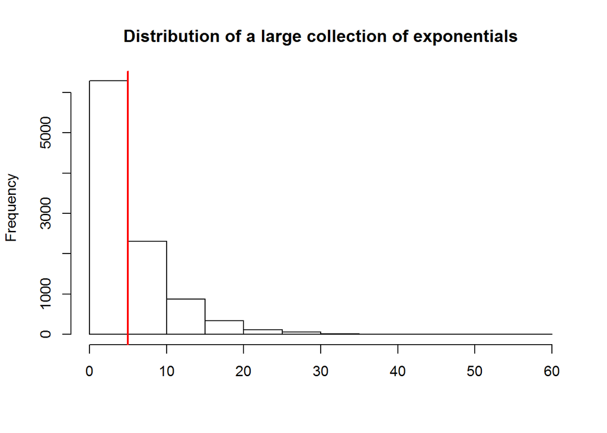

```r
theory_distrib<-rexp(10000,lambda)

hist(theory_distrib,main = "Distribution of a large collection of exponentials",xlab="")
#Mean of the theoretical distribution was calculated earlier and we know is 5
abline(v=theory_mn, col="red",lwd=2)
```

### Perform simulations

```r
set.seed(23)

sim_mns = NULL
for (i in 1 : 1000) sim_mns = c(sim_mns, mean(rexp(40,lambda)))
```